# Part I: Exploratory Data Analysis - Prosper Loan

## George Thomas

## Overview

> This analysis identified some factors that influence the Borrower Annual Percentage Rate (Borrower APR).

> Summary of findings
- Prosper started the loan business in 2005 with 22 loans recorded. The number of loans steadily increased till 2008 and reached 11552 loans. Then, the loans droppped till 2047 loans in 2009.
- The Borrowers APR distribution can be said to be multimodal. The loan amounts are right skewed with a few peaks. The analysis discovered the most frequently loaned amount to be 4,000. There are three loan terms available. The 36-month loan term is the highest used and many of the borrowers have a "current" loan status.
- The most common loan category is Debt Consolidation. In terms of distribution, the monthly income is right skewed.
- Borrower Rate correlates negatively with the original loan amount. It was observed that the loan amount varies inversely with the percentage paid. Meaning, the higher the loan amount, the lower the Borrower APR.

### Overview Continued

- Also, the loan status varies directly with the loan amount. Therefore, a higher loan amount causes a higher term status for any loan repayment. Borrowers that have a higher monthly income can access higher loan amounts, and are aable to pay higher loan amounts.
- The higher the loan amount, the higher the monthly repayment amount. Borrowers who have homes are more attractive in terms of getting high loan amounts because they usually have a high employment history and monthly income. Borrowers without homes are loaned between 0 and 5000, with a maximum of 30,000.
- The loan with 36-month repayment duration showed the borrowers annual percentage rate as a range of 0 to 0.4. There are a few outliers however, these outliers went as high as 0.5. Loans with 60-month term focused on larger loan amounts and borrowers APR of between 0.1 - 0.35.

### Overview Continued

- The 12-month loan term were focused majorly for lower loan amounts where the borrower APR ranged from 0 to 0.35. The term did not seem to have an effect string enough to strenghten or cause an effect on the Borrowers APR.
- For loans with a maximum duration of 12 months, the fee charged for these loans were higher than the 36- and 60-months terms.

## Dataset Overview

> This data set contains information loans facilitated by credit company Prosper. There are 113,937 loans with 81 variables. 13 variables were chosen for this analysis:
> - 'Term', 'LoanStatus', 'BorrowerAPR', 'ProsperScore', 'ListingCategory (numeric)', 'EmploymentStatus', 'EmploymentStatusDuration', 'IsBorrowerHomeowner', 'DebtToIncomeRatio', 'StatedMonthlyIncome', 'LoanOriginalAmount', 'LoanOriginationDate', 'MonthlyLoanPayment'

## Exploration Analyis Question

> Factors that affect the borrowers annual percentage rate (BorrowerAPR)?

## Borrower APR Distribution

> The distribution of the borrowers annual distribution rate is multimodal with several peaks.

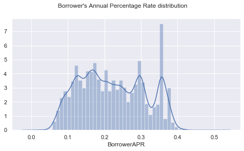

## Correlation Analysis Between all variables

> Relationships to be explored are **"Term vs LoanOriginalAmount", "BorrowerAPR vs LoanOriginalAmount" and "LoanOriginalAmount vs MonthlyLoanPayment"**

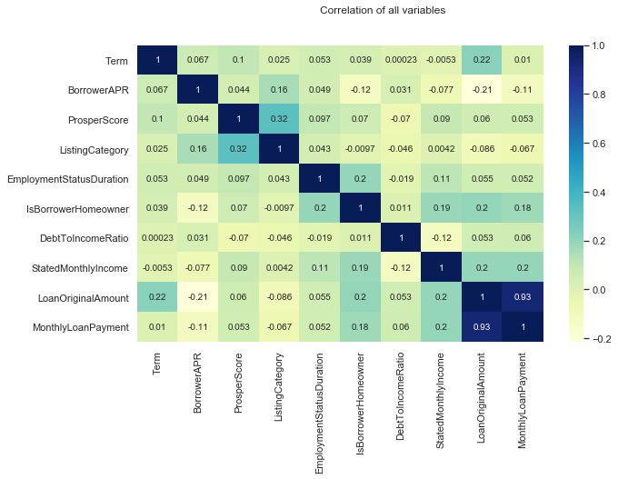

## Term vs Loan Original Amount

> The higher the loan amount the higher the term status given for loan repayment.

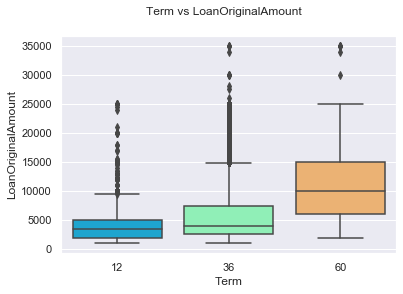

## BorrowerAPR vs LoanOriginalAmount

> - The higher the loan amount obtained the lower the borrowers annual percentage rate

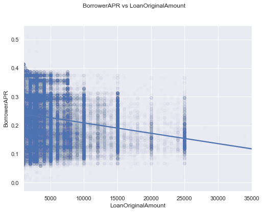

## LoanOriginalAmount vs MonthlyLoanPayment

> The higher the loan amount the higher the monthly repayment amount

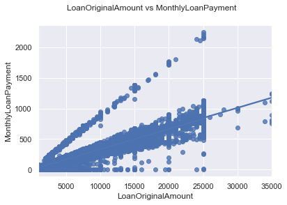

## LoanOriginalAmount vs BorrowerAPR vs Term

> The 36 months term loans have borrowers annual rate percentage between 0 - 0.4 with a few outliers going to 0.5, Loans for 60 months term are concentrated more on the higher loan amounts and borrowers APR between 0.1 - 0.35, while the 12 months loan term are majorly for lowe loan amounts with a borrowerAPR between 0 - 0.35.

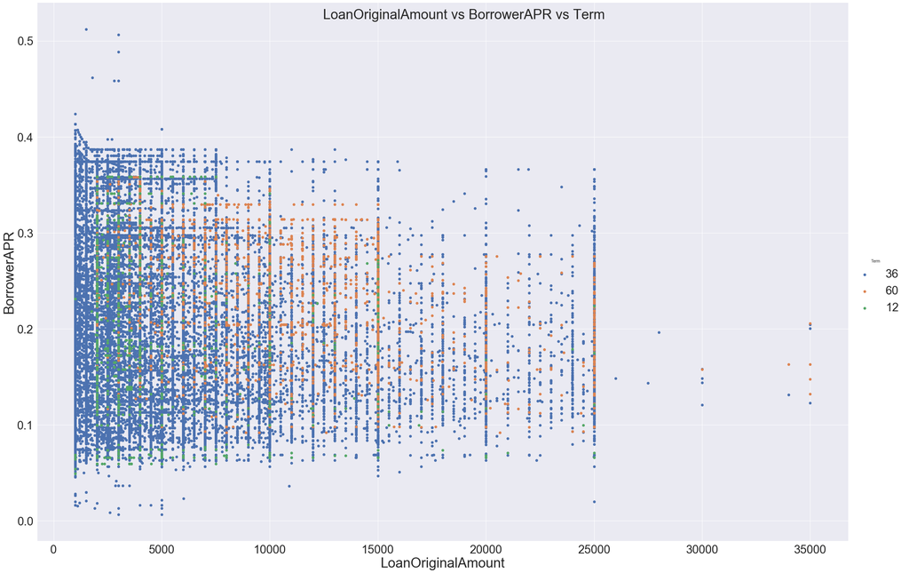

## LoanOriginalAmount vs MonthlyLoanPayment vs Term

> The effect of the loan terms on the Monthly loan payment to be paid back depending on loan amount. - For loans that cover only 12 months, the monthly fee tends to be more than the other terms since it is a shorter term. While the loans are more spread across for loan terms of 60 months.

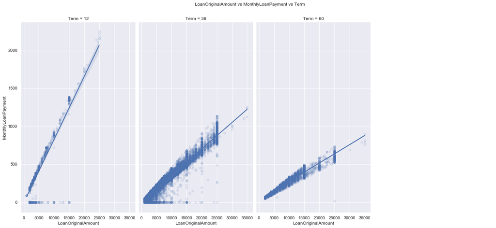